# EDA

2023-03-07

# Exploratory data analysis

Data spans average daily temperature from Kosice International Airport from $2009$ to $2022$ and daily mean averaged over $1981-2010$ for comparison of the temperature to be expected on a given day from historical data.

```r
library(tidyverse)
# load data (see SHMU_scraping.R for web scraping script)
temp_nonleap <- read_rds("temp_nonleap.rds")
temp_leap <- read_rds("temp_leap.rds")
```

View each of the datasets.

```r
temp_leap %>% slice_head(n=10)
```

| date2012 | temp2012 | longterm_temp2012 | date2016 | temp2016 | longterm_temp2016 | date2020 | temp2020 | longterm_temp2020 |
| --- | --- | --- | --- | --- | --- | --- | --- | --- |
| 2012-01-01 | -0.5 | -2.4 | 2016-01-01 | -8.1 | -2.4 | 2020-01-01 | -1.0 | -2.4 |
| 2012-01-02 | 2.5 | -2.4 | 2016-01-02 | -9.6 | -2.4 | 2020-01-02 | -3.8 | -2.4 |
| 2012-01-03 | 3.5 | -2.6 | 2016-01-03 | -9.5 | -2.6 | 2020-01-03 | -3.7 | -2.6 |
| 2012-01-04 | 2.8 | -2.5 | 2016-01-04 | -9.8 | -2.5 | 2020-01-04 | -3.1 | -2.5 |
| 2012-01-05 | 1.3 | -2.7 | 2016-01-05 | -6.9 | -2.7 | 2020-01-05 | -1.0 | -2.7 |
| 2012-01-06 | 3.2 | -3.0 | 2016-01-06 | -1.8 | -3.0 | 2020-01-06 | -2.6 | -3.0 |
| 2012-01-07 | 0.6 | -3.0 | 2016-01-07 | 0.9 | -3.0 | 2020-01-07 | -4.0 | -3.0 |
| 2012-01-08 | -0.2 | -3.1 | 2016-01-08 | -2.9 | -3.1 | 2020-01-08 | -4.0 | -3.1 |
| 2012-01-09 | 1.2 | -2.7 | 2016-01-09 | 0.0 | -2.7 | 2020-01-09 | -2.5 | -2.7 |
| 2012-01-10 | 0.2 | -2.2 | 2016-01-10 | 1.7 | -2.2 | 2020-01-10 | -1.1 | -2.2 |

```r
temp_nonleap %>% slice_head(n=10)
```

| date2009 | temp2009 | longterm_temp2009 | date2010 | temp2010 | longterm_temp2010 | date2011 | temp2011 | longterm_temp2011 | date2013 | temp2013 | longterm_temp2013 | date2014 | temp2014 | longterm_temp2014 | date2015 | temp2015 | longterm_temp2015 | date2017 | temp2017 | longterm_temp2017 | date2018 | temp2018 | longterm_temp2018 | date2019 | temp2019 | longterm_temp2019 | date2021 | temp2021 | longterm_temp2021 | … |
| --- | --- | --- | --- | --- | --- | --- | --- | --- | --- | --- | --- | --- | --- | --- | --- | --- | --- | --- | --- | --- | --- | --- | --- | --- | --- | --- | --- | --- | --- | --- |
| 2009-01-01 | -7.3 | -2.4 | 2010-01-01 | 4.8 | -2.4 | 2011-01-01 | -5.7 | -2.4 | 2013-01-01 | -3.9 | -2.4 | 2014-01-01 | 1.9 | -2.4 | 2015-01-01 | -5.0 | -2.4 | 2017-01-01 | -4.9 | -2.4 | 2018-01-01 | 3.0 | -2.4 | 2019-01-01 | 0.7 | -2.4 | 2021-01-01 | 4.0 | -2.4 | … |
| 2009-01-02 | -6.0 | -2.4 | 2010-01-02 | 1.5 | -2.4 | 2011-01-02 | -3.4 | -2.4 | 2013-01-02 | -3.5 | -2.4 | 2014-01-02 | 3.2 | -2.4 | 2015-01-02 | -4.8 | -2.4 | 2017-01-02 | -4.8 | -2.4 | 2018-01-02 | 4.8 | -2.4 | 2019-01-02 | 1.2 | -2.4 | 2021-01-02 | 3.9 | -2.4 | … |
| 2009-01-03 | -9.3 | -2.6 | 2010-01-03 | -3.6 | -2.6 | 2011-01-03 | -4.0 | -2.6 | 2013-01-03 | -2.7 | -2.6 | 2014-01-03 | 3.3 | -2.6 | 2015-01-03 | -2.1 | -2.6 | 2017-01-03 | -5.9 | -2.6 | 2018-01-03 | 2.4 | -2.6 | 2019-01-03 | -1.9 | -2.6 | 2021-01-03 | 4.4 | -2.6 | … |
| 2009-01-04 | -7.5 | -2.5 | 2010-01-04 | -5.7 | -2.5 | 2011-01-04 | -5.6 | -2.5 | 2013-01-04 | 0.9 | -2.5 | 2014-01-04 | 4.5 | -2.5 | 2015-01-04 | -0.5 | -2.5 | 2017-01-04 | 0.3 | -2.5 | 2018-01-04 | 2.1 | -2.5 | 2019-01-04 | -3.8 | -2.5 | 2021-01-04 | 6.4 | -2.5 | … |
| 2009-01-05 | -6.1 | -2.7 | 2010-01-05 | -3.4 | -2.7 | 2011-01-05 | -5.4 | -2.7 | 2013-01-05 | 2.8 | -2.7 | 2014-01-05 | 6.1 | -2.7 | 2015-01-05 | -0.8 | -2.7 | 2017-01-05 | -4.2 | -2.7 | 2018-01-05 | 3.6 | -2.7 | 2019-01-05 | -4.0 | -2.7 | 2021-01-05 | 4.6 | -2.7 | … |
| 2009-01-06 | -10.5 | -3.0 | 2010-01-06 | -0.5 | -3.0 | 2011-01-06 | -3.8 | -3.0 | 2013-01-06 | 0.3 | -3.0 | 2014-01-06 | 6.8 | -3.0 | 2015-01-06 | -4.9 | -3.0 | 2017-01-06 | -12.0 | -3.0 | 2018-01-06 | 5.3 | -3.0 | 2019-01-06 | -3.3 | -3.0 | 2021-01-06 | 3.8 | -3.0 | … |
| 2009-01-07 | -8.5 | -3.0 | 2010-01-07 | -0.8 | -3.0 | 2011-01-07 | -0.3 | -3.0 | 2013-01-07 | -2.6 | -3.0 | 2014-01-07 | 5.9 | -3.0 | 2015-01-07 | -9.2 | -3.0 | 2017-01-07 | -13.1 | -3.0 | 2018-01-07 | 7.0 | -3.0 | 2019-01-07 | -6.5 | -3.0 | 2021-01-07 | 1.1 | -3.0 | … |
| 2009-01-08 | -10.0 | -3.1 | 2010-01-08 | 1.8 | -3.1 | 2011-01-08 | 1.2 | -3.1 | 2013-01-08 | -4.1 | -3.1 | 2014-01-08 | 5.5 | -3.1 | 2015-01-08 | -7.3 | -3.1 | 2017-01-08 | -8.7 | -3.1 | 2018-01-08 | 5.8 | -3.1 | 2019-01-08 | -6.8 | -3.1 | 2021-01-08 | 0.2 | -3.1 | … |
| 2009-01-09 | -11.7 | -2.7 | 2010-01-09 | 5.2 | -2.7 | 2011-01-09 | 1.4 | -2.7 | 2013-01-09 | -4.7 | -2.7 | 2014-01-09 | 3.7 | -2.7 | 2015-01-09 | -3.1 | -2.7 | 2017-01-09 | -6.8 | -2.7 | 2018-01-09 | 4.6 | -2.7 | 2019-01-09 | -4.9 | -2.7 | 2021-01-09 | -2.1 | -2.7 | … |
| 2009-01-10 | -5.9 | -2.2 | 2010-01-10 | 4.3 | -2.2 | 2011-01-10 | 3.1 | -2.2 | 2013-01-10 | -5.1 | -2.2 | 2014-01-10 | 2.3 | -2.2 | 2015-01-10 | 2.1 | -2.2 | 2017-01-10 | -11.4 | -2.2 | 2018-01-10 | 4.7 | -2.2 | 2019-01-10 | -2.0 | -2.2 | 2021-01-10 | -1.0 | -2.2 | … |

### Weekly plot

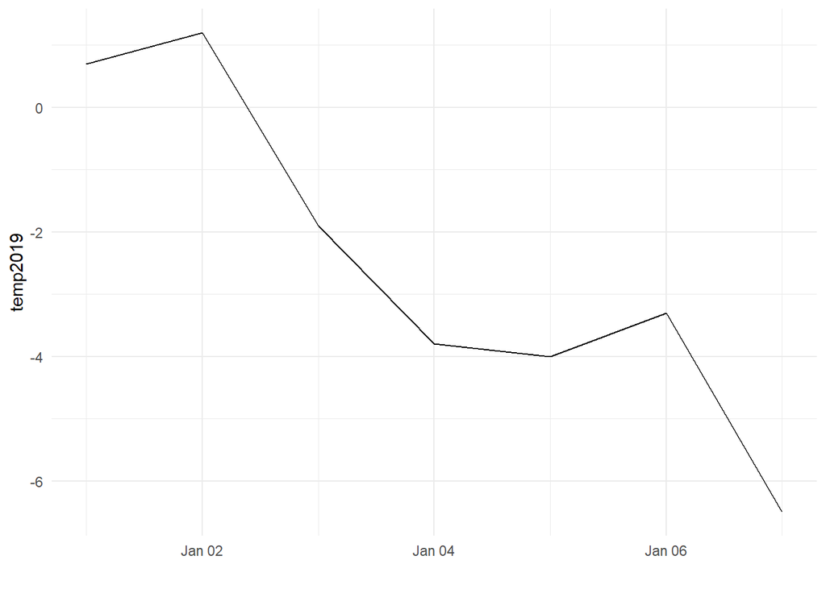

```r
temp_nonleap[1:7,] %>%
ggplot(aes(x=date2019,y=temp2019)) + geom_line() + theme_minimal() + xlab("")
```

Hard to see any trends.

### Monthly plot

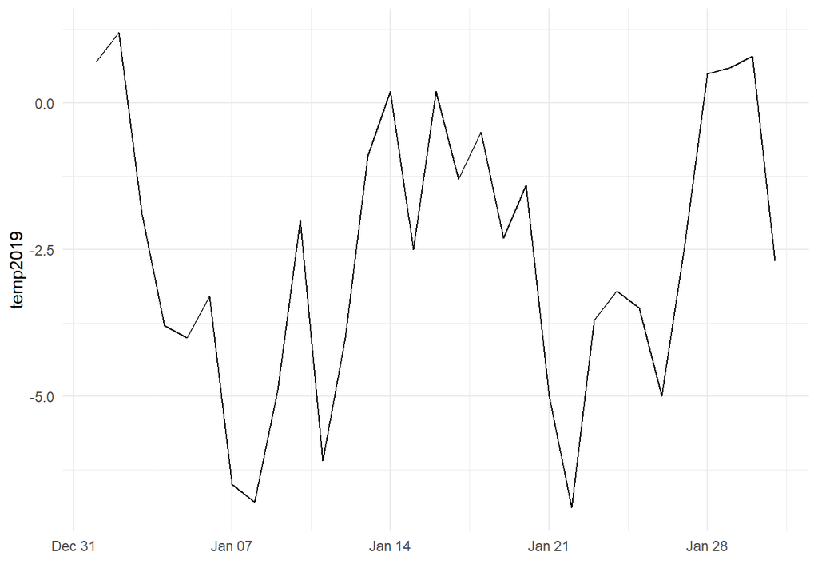

```r
temp_nonleap[1:31,] %>%
ggplot(aes(x=date2019,y=temp2019)) + geom_line() + theme_minimal() + xlab("")
```

Too much variation, daily temperature is quite variable.

### Yearly plot

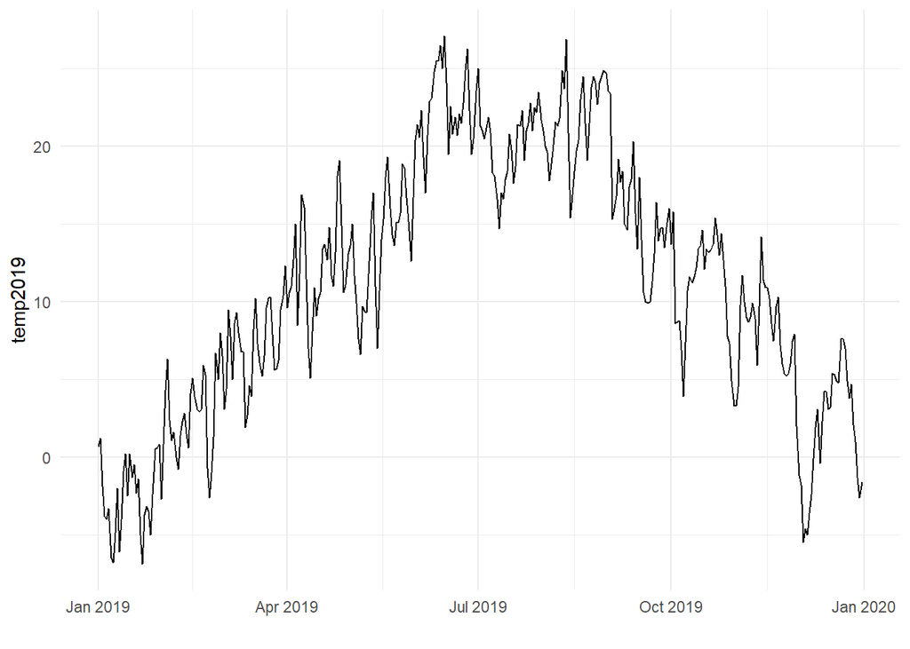

```r
temp_nonleap %>%  ggplot(aes(x=date2019,y=temp2019)) + geom_line() + theme_minimal() + xlab("")
```

### All the years

```r
#temp_nonleap %>%  pivot_longer(starts_with("date"))
# create empty dataframe
long_temp <- data.frame(matrix(nrow=0,ncol=3))
colnames(long_temp) <- c("date","temp","longterm_temp")
for (i in 1:11) {
  colnames(temp_nonleap)[c(3*i-2,3*i-1,3*i)] <- c("date","temp","longterm_temp")
 long_temp <- rbind(long_temp,temp_nonleap[,c(3*i-2,3*i-1,3*i)])
}

for (i in 1:3) {
  colnames(temp_leap)[c(3*i-2,3*i-1,3*i)] <- c("date","temp","longterm_temp")
 long_temp <- rbind(long_temp,temp_leap[,c(3*i-2,3*i-1,3*i)])
}

long_temp <- long_temp %>% arrange(date)
```

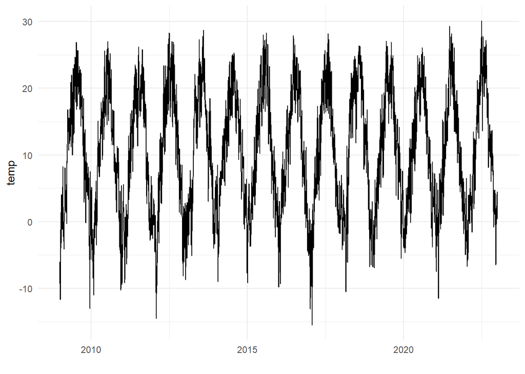

```r
long_temp %>%  ggplot(aes(x=date,y=temp)) + geom_line() + theme_minimal() + xlab("")
```

For completeness, show also longterm temperature.

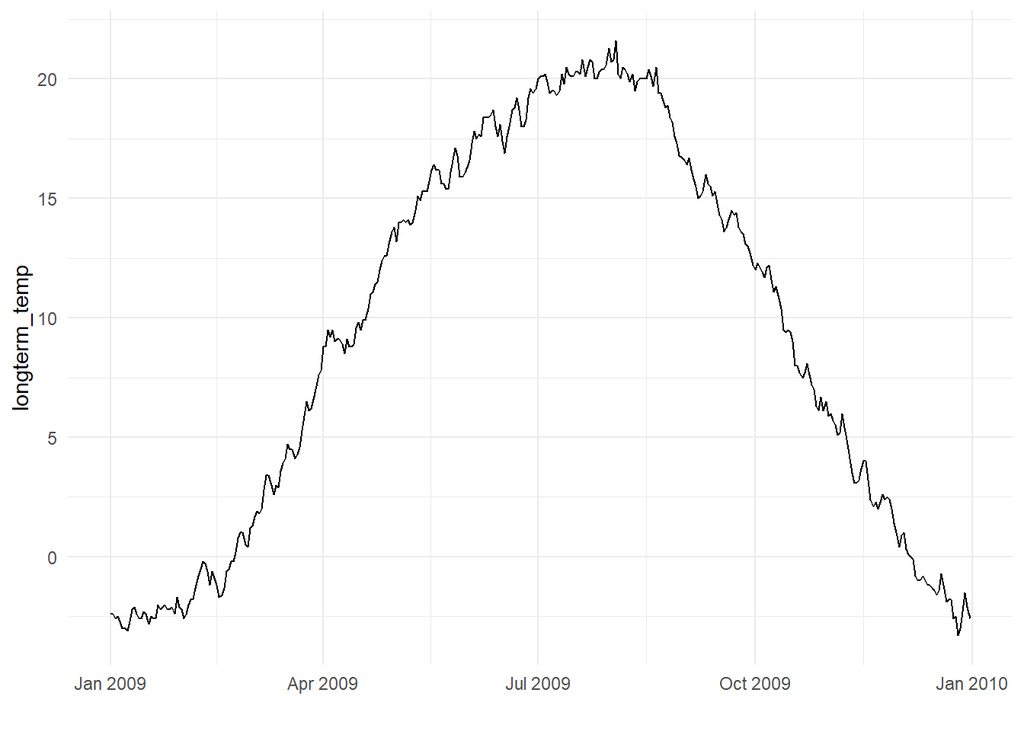

```r
long_temp[1:365,] %>%  ggplot(aes(x=date,y=longterm_temp)) + geom_line() + theme_minimal() + xlab("")
```

Plot both temperatures on the same plot.

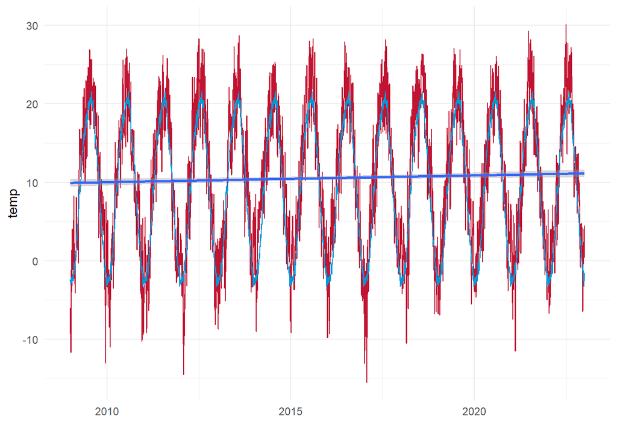

```r
long_temp %>%  ggplot() + geom_line(aes(x=date,y=temp),col= "#C11432") + geom_line(aes(x=date,y=longterm_temp),col="#009ADA") +
  geom_smooth(aes(x=date,y=temp),method = "lm") +
    scale_x_date() +
  theme_minimal() + xlab("")
```

Clearly, some average needs to be taken.

## More precise approach

```r
# print wrangled data
long_temp
```

| date | temp | longterm_temp |
| --- | --- | --- |
| 2009-01-01 | -7.3 | -2.4 |
| 2009-01-02 | -6.0 | -2.4 |
| 2009-01-03 | -9.3 | -2.6 |
| 2009-01-04 | -7.5 | -2.5 |
| 2009-01-05 | -6.1 | -2.7 |
| 2009-01-06 | -10.5 | -3.0 |
| 2009-01-07 | -8.5 | -3.0 |
| 2009-01-08 | -10.0 | -3.1 |
| 2009-01-09 | -11.7 | -2.7 |
| 2009-01-10 | -5.9 | -2.2 |

[output cut: 5103 more lines]

Add a column for a difference with the daily average.

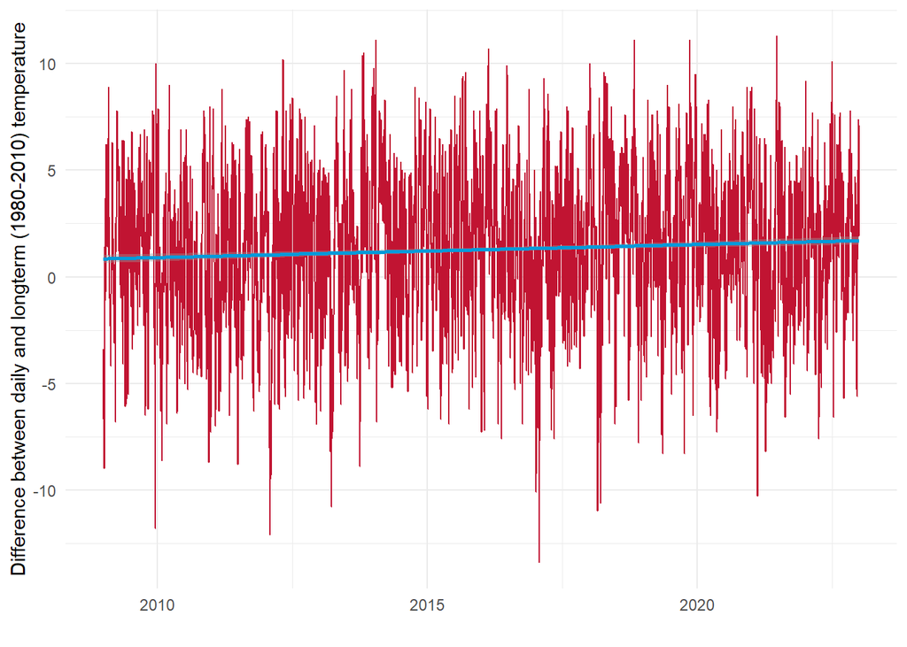

```r
long_temp <- long_temp %>% mutate(temp_diff=temp-longterm_temp)
long_temp %>%  ggplot() + geom_line(aes(x=date,y=temp_diff),col= "#C11432")  +
  geom_smooth(aes(x=date,y=temp_diff),method="lm",col='#009ADA') +
  ylab("Difference between daily and longterm (1980-2010) temperature") +
  theme_minimal() + xlab("")
```

```r
library(tseries)
library(forecast)
```

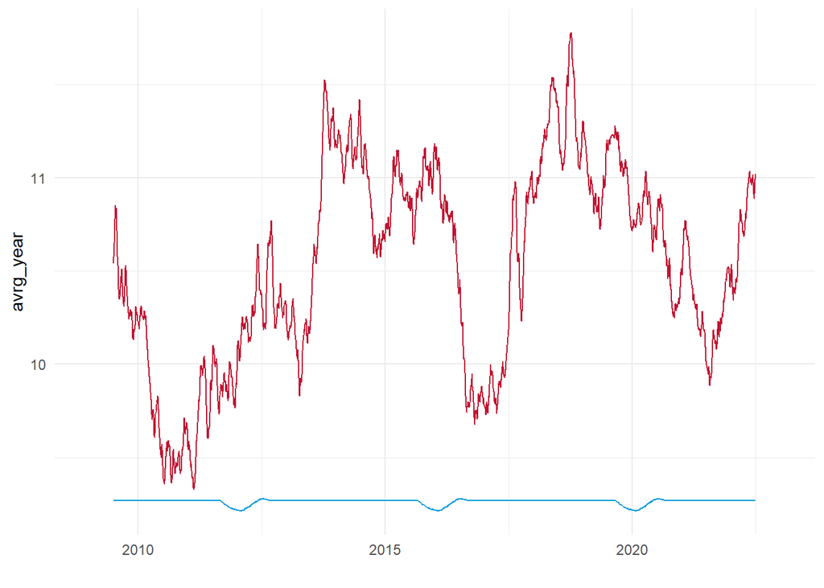

```r
# add yearly moving average
long_temp <- long_temp %>% mutate(avrg_year=ma(temp,365)) %>%  mutate(avrg_year_long=ma(longterm_temp,365))
long_temp %>%  ggplot() + geom_line(aes(x=date,y=avrg_year),col= "#C11432") + geom_line(aes(x=date,y=avrg_year_long),col="#009ADA") + theme_minimal() + xlab("")
```

### Aggregate by year

```r
year_mean <- c()
long_mean <- c()
for (i in 2009:2022) {
  year_start <- paste0(i,'-01-01')
  year_end <- paste0(i,'-12-31')
  year_mean[i-2008] <- long_temp %>% filter(date >= year_start & date <= year_end) %>% select(temp) %>% pull() %>%  mean()
  long_mean[i-2008] <- long_temp %>% filter(date >= year_start & date <= year_end) %>% select(longterm_temp) %>% pull() %>% mean()
}
year_mean_df <- data.frame(year=2009:2022,temp_mean=year_mean,longterm_mean=long_mean,our_mean=rep(mean(year_mean),14))
year_mean_df
```

| year | temp_mean | longterm_mean | our_mean |
| --- | --- | --- | --- |
| 2009 | 10.541644 | 9.269315 | 10.54251 |
| 2010 | 9.429589 | 9.269315 | 10.54251 |
| 2011 | 9.987123 | 9.269315 | 10.54251 |
| 2012 | 10.326503 | 9.246175 | 10.54251 |
| 2013 | 10.300274 | 9.269315 | 10.54251 |
| 2014 | 11.269315 | 9.269315 | 10.54251 |
| 2015 | 10.905205 | 9.269315 | 10.54251 |
| 2016 | 10.348907 | 9.246175 | 10.54251 |
| 2017 | 10.205205 | 9.269315 | 10.54251 |
| 2018 | 11.385205 | 9.269315 | 10.54251 |

[output cut: 4 more lines]

Due to leap years, yearly mean cannot be constant. It can be observed that ommiting data from February, $29$ will increase the yearly longterm mean only by $0.02$ degrees.

```r
year_mean <- year_mean_df %>% mutate(longterm_mean=rep(long_mean[1],14))
year_mean
```

| year | temp_mean | longterm_mean | our_mean |
| --- | --- | --- | --- |
| 2009 | 10.541644 | 9.269315 | 10.54251 |
| 2010 | 9.429589 | 9.269315 | 10.54251 |
| 2011 | 9.987123 | 9.269315 | 10.54251 |
| 2012 | 10.326503 | 9.269315 | 10.54251 |
| 2013 | 10.300274 | 9.269315 | 10.54251 |
| 2014 | 11.269315 | 9.269315 | 10.54251 |
| 2015 | 10.905205 | 9.269315 | 10.54251 |
| 2016 | 10.348907 | 9.269315 | 10.54251 |
| 2017 | 10.205205 | 9.269315 | 10.54251 |
| 2018 | 11.385205 | 9.269315 | 10.54251 |

[output cut: 4 more lines]

Now, plot these.

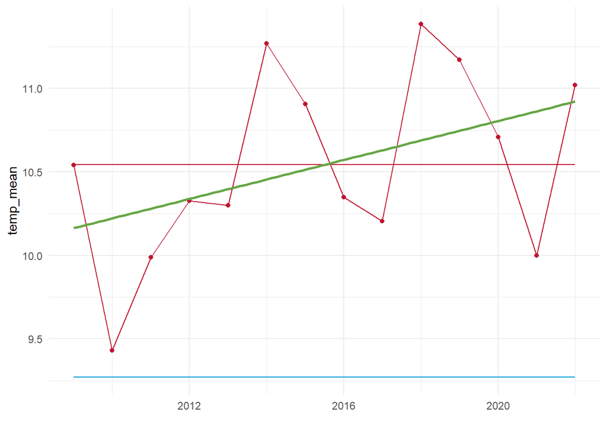

```r
year_mean %>%  ggplot() + geom_line(aes(x=year,y=temp_mean),col= "#C11432")+ geom_point(aes(x=year,y=temp_mean),col= "#C11432") + geom_line(aes(x=year,y=longterm_mean),col="#009ADA") +
  geom_line(aes(x=year,y=our_mean),col='#C11432') +
  theme_minimal() + xlab("") +
  geom_smooth(aes(x=year,y=temp_mean),method='lm', se = FALSE,col='#66A646')
```

If there was no warming, it would be assumed that the area between the blue and red line should be about zero. However, we can see that the red line stays persistently above blue line which is another indicator of global warming.

Now try the same with monthly temperature average.

```r
month_mean <- c()
long_mean <- c()
mean_start <- c()
mean_end <- c()
for (i in 2009:2022) {
  for (j in 1:12) {
  month_start <- as.Date(paste0(i,'-',j,'-01'))
  month_end <- as.Date(paste0(i+floor(j/12),'-',(j%%12) + 1,'-01'))
  month_mean[(i-2009)*12+j] <- long_temp %>% filter(date >= month_start & date < month_end) %>% select(temp) %>% pull() %>%  mean()
  long_mean[(i-2009)*12+j] <- long_temp %>% filter(date >= month_start & date < month_end) %>% select(longterm_temp) %>% pull() %>% mean()
  mean_start[(i-2009)*12+j] <- paste0(i,'-',j,'-01')
    mean_end[(i-2009)*12+j] <- paste0(i+floor(j/12),'-',(j%%12)+1,'-01')
  }
}
month_mean_df <- data.frame(mean_start=mean_start,mean_end=mean_end,temp_mean=month_mean,longterm_mean=long_mean) %>%
  mutate(mean_start=as.Date(mean_start),mean_end=as.Date(mean_end) )
month_mean_df <-  month_mean_df %>% mutate(temp_diff=temp_mean-longterm_mean)
month_mean_df
```

| mean_start | mean_end | temp_mean | longterm_mean | temp_diff |
| --- | --- | --- | --- | --- |
| 2009-01-01 | 2009-02-01 | -2.86774194 | -2.4096774 | -0.45806452 |
| 2009-02-01 | 2009-03-01 | 0.27500000 | -0.7285714 | 1.00357143 |
| 2009-03-01 | 2009-04-01 | 4.39354839 | 4.1387097 | 0.25483871 |
| 2009-04-01 | 2009-05-01 | 13.95666667 | 10.2133333 | 3.74333333 |
| 2009-05-01 | 2009-06-01 | 16.07419355 | 15.2483871 | 0.82580645 |
| 2009-06-01 | 2009-07-01 | 18.23666667 | 18.1433333 | 0.09333333 |
| 2009-07-01 | 2009-08-01 | 21.65161290 | 20.1645161 | 1.48709677 |
| 2009-08-01 | 2009-09-01 | 21.02258065 | 19.5225806 | 1.50000000 |
| 2009-09-01 | 2009-10-01 | 17.46666667 | 14.6666667 | 2.80000000 |
| 2009-10-01 | 2009-11-01 | 9.66451613 | 9.2516129 | 0.41290323 |

[output cut: 158 more lines]

Add the same plot.

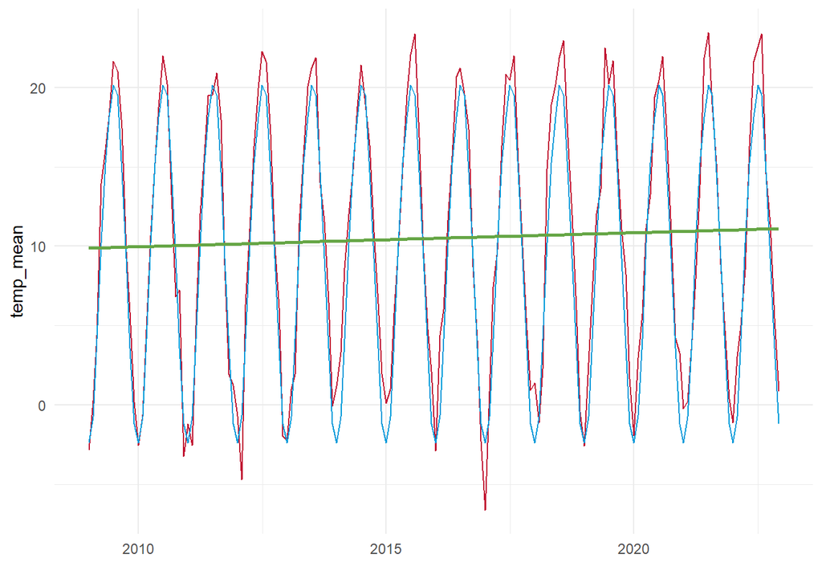

```r
month_mean_df %>%  ggplot() + geom_line(aes(x=mean_start,y=temp_mean),col= "#C11432") + geom_line(aes(x=mean_start,y=longterm_mean),col="#009ADA") + theme_minimal() + xlab("") +
  geom_smooth(aes(x=mean_start,y=temp_mean),method='lm', se = FALSE,col='#66A646')
```

Do the same for temperature difference.

```r
month_mean_df$mean_start <- as.POSIXct(month_mean_df$mean_start,tz="UTC")
month_mean_df$mean_end <- as.POSIXct(month_mean_df$mean_end,tz="UTC")
month_mean_df
```

| mean_start | mean_end | temp_mean | longterm_mean | temp_diff |
| --- | --- | --- | --- | --- |
| 2009-01-01 00:00:00 | 2009-02-01 00:00:00 | -2.86774194 | -2.4096774 | -0.45806452 |
| 2009-02-01 00:00:00 | 2009-03-01 00:00:00 | 0.27500000 | -0.7285714 | 1.00357143 |
| 2009-03-01 00:00:00 | 2009-04-01 01:00:00 | 4.39354839 | 4.1387097 | 0.25483871 |
| 2009-04-01 01:00:00 | 2009-05-01 01:00:00 | 13.95666667 | 10.2133333 | 3.74333333 |
| 2009-05-01 01:00:00 | 2009-06-01 01:00:00 | 16.07419355 | 15.2483871 | 0.82580645 |
| 2009-06-01 01:00:00 | 2009-07-01 01:00:00 | 18.23666667 | 18.1433333 | 0.09333333 |
| 2009-07-01 01:00:00 | 2009-08-01 01:00:00 | 21.65161290 | 20.1645161 | 1.48709677 |
| 2009-08-01 01:00:00 | 2009-09-01 01:00:00 | 21.02258065 | 19.5225806 | 1.50000000 |
| 2009-09-01 01:00:00 | 2009-10-01 01:00:00 | 17.46666667 | 14.6666667 | 2.80000000 |
| 2009-10-01 01:00:00 | 2009-11-01 00:00:00 | 9.66451613 | 9.2516129 | 0.41290323 |

[output cut: 158 more lines]

Create colour scale.

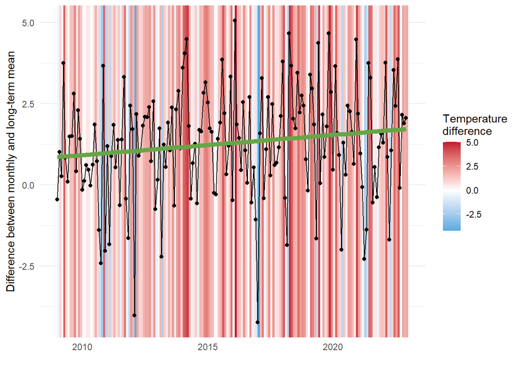

```r
p <- ggplot(month_mean_df) +  geom_rect(alpha=1,aes(xmin=mean_start,xmax=mean_end,ymin=-Inf,ymax=+Inf,fill=temp_diff)) + scale_fill_gradient2(low='#009ADA',high='#C11432',mid='#FEFEFE',name="Temperature\ndifference") +
   theme(legend.key.height=unit(2, "cm"))
p  + geom_line(aes(x=mean_start,y=temp_mean-longterm_mean),col= "black") +
  geom_point(aes(x=mean_start,y=temp_mean-longterm_mean),col= "black")+ theme_minimal() + xlab("") +
  geom_smooth(aes(x=mean_start,y=temp_mean-longterm_mean),method='lm', se = FALSE,col='#66A646',size=2) +
  ylab("Difference between monthly and long-term mean")
```

Plot layer by layer.

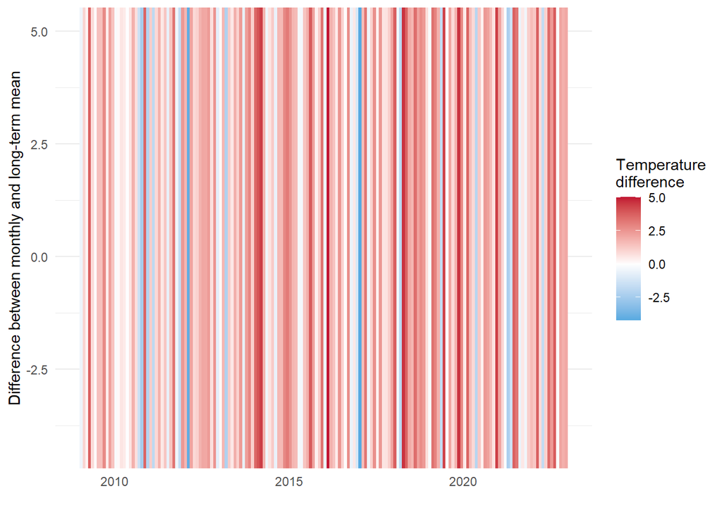

```r
p <- ggplot(month_mean_df) +  geom_rect(alpha=1,aes(xmin=mean_start,xmax=mean_end,ymin=-Inf,ymax=+Inf,fill=temp_diff)) + scale_fill_gradient2(low='#009ADA',high='#C11432',mid='#FEFEFE',name="Temperature\ndifference") +
   theme(legend.key.height=unit(2, "cm"))
p+
  geom_point(aes(x=mean_start,y=temp_mean-longterm_mean),col= "black",alpha=0)+ theme_minimal() + xlab("") +
   ylab("Difference between monthly and long-term mean")
```

### Perform t-test on $\mu=0$

```r
mu <- month_mean_df %>% pull(temp_diff)
mean(mu)/(sd(mu)/sqrt(length(mu)))
```

```
## [1] 9.808895
```

```r
t.test(x = mu,mu=0)
```

```
##
##  One Sample t-test
##
## data:  mu
## t = 9.8089, df = 167, p-value < 2.2e-16
## alternative hypothesis: true mean is not equal to 0
## 95 percent confidence interval:
##  1.024565 1.540932
## sample estimates:
## mean of x
##  1.282749
```

### Simple linear regression

```r
month_mean_df <-  month_mean_df %>% mutate(t=1:168)
lm(temp_diff~t,data=month_mean_df) %>% summary()
```

```
##
## Call:
## lm(formula = temp_diff ~ t, data = month_mean_df)
##
## Residuals:
##     Min      1Q  Median      3Q     Max
## -5.5893 -0.9482  0.1255  1.1093  3.7612
##
## Coefficients:
##             Estimate Std. Error t value Pr(>|t|)
## (Intercept) 0.846187   0.260598   3.247  0.00141 **
## t           0.005166   0.002675   1.932  0.05512 .
## ---
## Signif. codes:  0 '***' 0.001 '**' 0.01 '*' 0.05 '.' 0.1 ' ' 1
##
## Residual standard error: 1.681 on 166 degrees of freedom
## Multiple R-squared:  0.02198,    Adjusted R-squared:  0.01609
## F-statistic: 3.731 on 1 and 166 DF,  p-value: 0.05512
```